# Vendor Channel Attribution

Jeffrey Uslan

November 17, 2015

# Synopsis

This report explores the contribution of site visit touch points on order completion. The purpose of this exploration is to assign appropriate “credit” for a purchase to the appropriate vendors.

# Exploration

The table below shows how many users are present in the purchase group and non-purchaser group.

| purchaser | Users |
| --- | --- |
| 0 | 28325 |
| 1 | 14635 |

The table below shows how users are distributed across each visit touch point and purchaser group. Note that that this tabulation does not account for users visiting multiple touch points, a common occurence.

| channel | purchaser | Users |
| --- | --- | --- |
| affiliates | 0 | 380 |
| affiliates | 1 | 236 |
| direct | 0 | 6026 |
| direct | 1 | 4286 |
| display | 0 | 4892 |
| display | 1 | 1334 |
| email | 0 | 1005 |
| email | 1 | 875 |
| organic | 0 | 6473 |
| organic | 1 | 3301 |
| paid | 0 | 9086 |
| paid | 1 | 4112 |
| referral | 0 | 463 |
| referral | 1 | 491 |

The table below shows the mean number of sessions at each visit touch point across purchaser groups. T-tests were performed for each variable and all tests, except the display, show that the differences between purchaser groups are statistically significant. The display touch point had a p-value of 0.36- implying that the mean display sessions were not different between purchasers and non-purchasers.

| purchaser | row_sums | affiliates | direct | display | email | organic | paid | referral |
| --- | --- | --- | --- | --- | --- | --- | --- | --- |
| 0 | 2.2 | 0.029 | 0.53 | 0.39 | 0.085 | 0.43 | 0.67 | 0.038 |
| 1 | 4.4 | 0.04 | 1.9 | 0.4 | 0.27 | 0.77 | 0.91 | 0.079 |

The diagram below represents the amount of non-purchasing users exposed to present combinations of media.

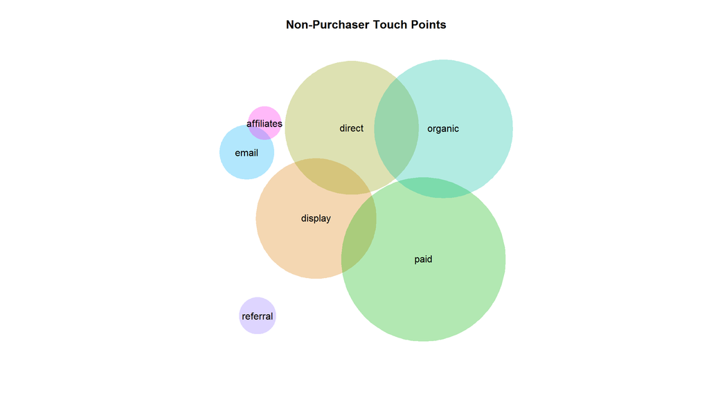

The table below shows the 6 most prevalent combinations of touch points among non-purchasers and the average number of sessions within those touch points.

| media_combo | purchaser | affiliates | direct | display | email | organic | paid | referral | Frequency |
| --- | --- | --- | --- | --- | --- | --- | --- | --- | --- |
| 0000010 | 0 | 0 | 0 | 0 | 0 | 0 | 1.6 | 0 | 0.28 |
| 0000100 | 0 | 0 | 0 | 0 | 0 | 1.4 | 0 | 0 | 0.19 |
| 0100000 | 0 | 0 | 1.8 | 0 | 0 | 0 | 0 | 0 | 0.17 |
| 0010000 | 0 | 0 | 0 | 1.7 | 0 | 0 | 0 | 0 | 0.13 |
| 0010010 | 0 | 0 | 0 | 2.3 | 0 | 0 | 2.4 | 0 | 0.034 |
| 0001000 | 0 | 0 | 0 | 0 | 1.8 | 0 | 0 | 0 | 0.033 |

The diagram below represents the amount of purchasing users exposed to present combinations of media.

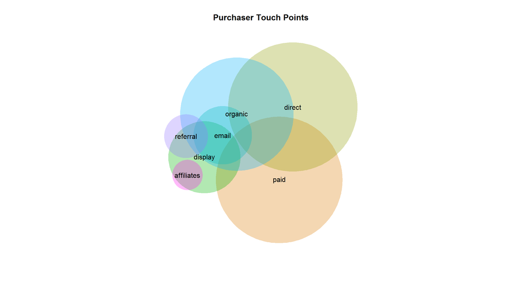

The table below shows the 6 most prevalent combinations of touch points among purchasers and the average number of sessions within those touch points.

| media_combo | purchaser | affiliates | direct | display | email | organic | paid | referral | Frequency |
| --- | --- | --- | --- | --- | --- | --- | --- | --- | --- |
| 0000010 | 1 | 0 | 0 | 0 | 0 | 0 | 1.5 | 0 | 0.2 |
| 0100000 | 1 | 0 | 2.4 | 0 | 0 | 0 | 0 | 0 | 0.17 |
| 0000100 | 1 | 0 | 0 | 0 | 0 | 1.5 | 0 | 0 | 0.12 |
| 0100100 | 1 | 0 | 3.7 | 0 | 0 | 1.8 | 0 | 0 | 0.078 |
| 0100010 | 1 | 0 | 3.1 | 0 | 0 | 0 | 1.6 | 0 | 0.062 |
| 0000110 | 1 | 0 | 0 | 0 | 0 | 2 | 1.8 | 0 | 0.042 |

The graph below shows the distribution of the number of distinct touch points experienced by users.

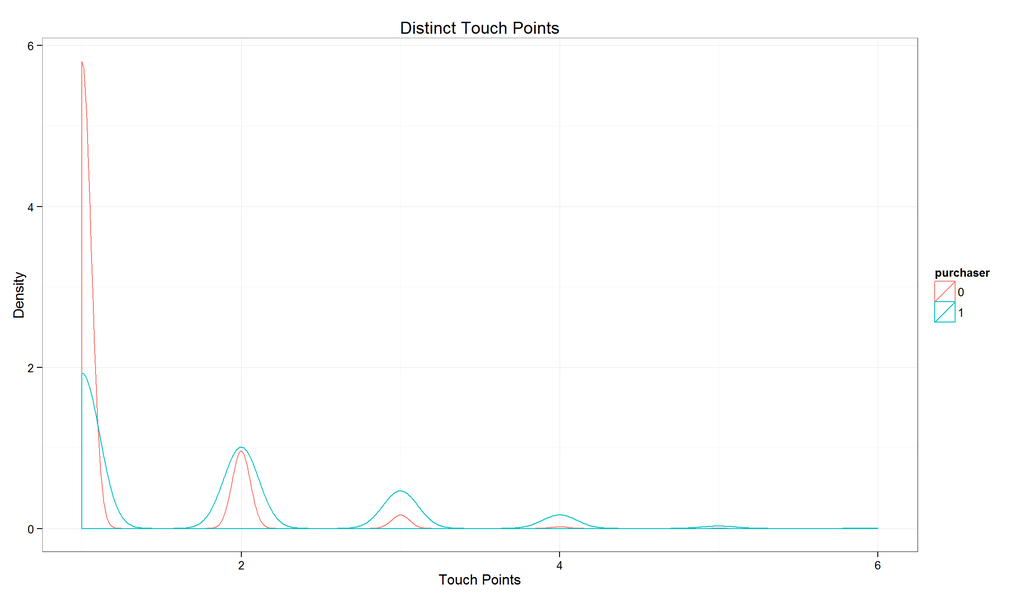

The graph below shows the correlative relationships of each variable. That is, how the number of sessions at a touchpoint correlates with the number of sessions at another.

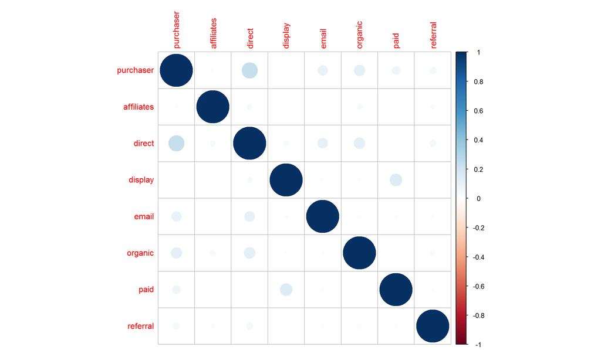

# Modeling

For validation purposes, the data were split into a training and test set. The split was made with 60% of the data alloted to model training and 40% to model testing.

The regularized regression classification model has an accuracy of 0.7491 on the training data, 0.7543 on the testing data, and 0.7512 combined.

The table below shows the coefficients produced by the linear classifier. Only non-interaction terms are listed, the effects of touch point negation have been isolated and removed. These coefficients can be thought of as the additive probability, per session, of a purchase occuring.

|  | Coefficients |
| --- | --- |
| **affiliates** | 0.079 |
| **direct** | 0.064 |
| **display** | 0.029 |
| **email** | 0.072 |
| **organic** | 0.093 |
| **paid** | 0.067 |
| **referral** | 0.077 |

The graphs below show how the values for each touch point contribute to the purchase status of a user. This comparison is done for observed values and predicted values from the model.

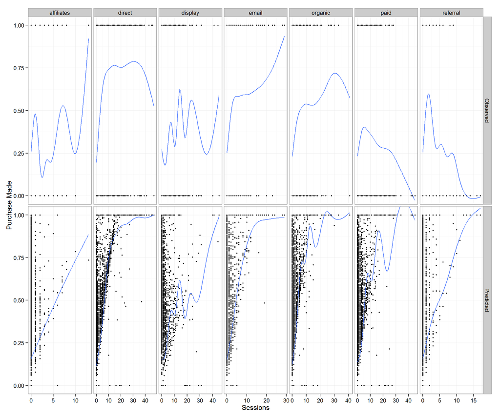

The linear classifier coefficients do not immediately indicate the predicitive power of each touch point, as the distribution of sessions is different between touch points. To identify which touch points have the most predicitive power we fit a random forest classifier, a bootstrapped decision tree. We then extract the accuracy contributions. The figure below shows how much accuracy would be lost if a variable were to be removed.

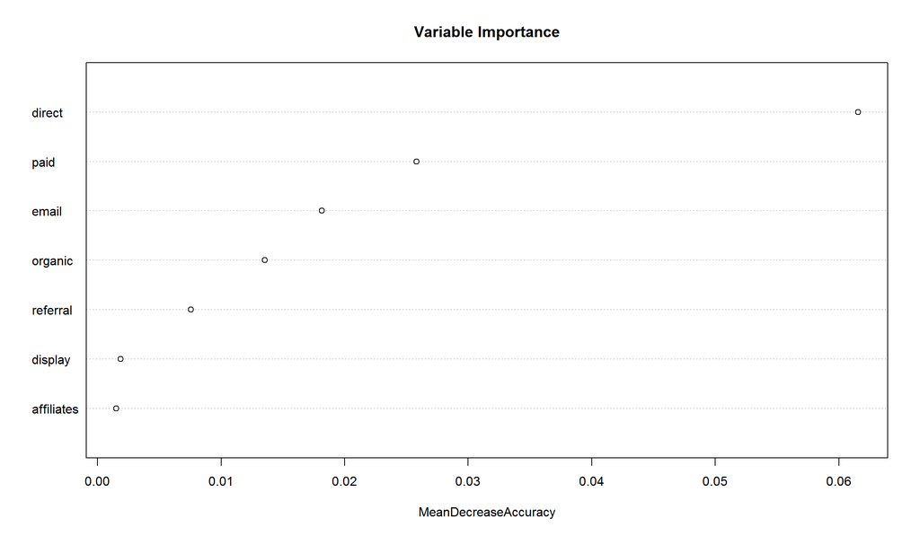